# EDA探索性分析

shydow

2018年12月12日

## EDA探索性分析

探索性数据分析（EDA）是数据项目的第一步，我们将创建一个代码模板来实现这一功能，EDA一般由单个变量（1个变量）和双变量分析组成

**第一步：取得并了解数据**  
**第二步：分析分类变量**  
**第三步：分析数值变量**  
**第四部：同时分析数值和分类变量**

基本EDA中的一些关键点：

**数据类型**  
**异常值**  
**缺失值**  
**数值和分类变量的分布（数字和图形的格式）**

### 分析结果的类型

*信息型*  
绘图或者任何长变量概要，我们无法从中过滤数据，但是他会立即提供大量的信息，用于描述性分析阶段  
*操作型*  
这类结果直接用于数据工作流（其中，选择缺失比例低于20%的变量），用于数据准备阶段

```r
library(tidyverse)
library(Hmisc)
library(funModeling)
```

```
## Observations: 303
## Variables: 16
## $ age                    <int> 63, 67, 67, 37, 41, 56, 62, 57, 63, 53,...
## $ gender                 <fct> male, male, male, male, female, male, f...
## $ chest_pain             <fct> 1, 4, 4, 3, 2, 2, 4, 4, 4, 4, 4, 2, 3, ...
## $ resting_blood_pressure <int> 145, 160, 120, 130, 130, 120, 140, 120,...
## $ serum_cholestoral      <int> 233, 286, 229, 250, 204, 236, 268, 354,...
## $ fasting_blood_sugar    <fct> 1, 0, 0, 0, 0, 0, 0, 0, 0, 1, 0, 0, 1, ...
## $ resting_electro        <fct> 2, 2, 2, 0, 2, 0, 2, 0, 2, 2, 0, 2, 2, ...
## $ max_heart_rate         <int> 150, 108, 129, 187, 172, 178, 160, 163,...
## $ exer_angina            <int> 0, 1, 1, 0, 0, 0, 0, 1, 0, 1, 0, 0, 1, ...
## $ oldpeak                <dbl> 2.3, 1.5, 2.6, 3.5, 1.4, 0.8, 3.6, 0.6,...
## $ slope                  <int> 3, 2, 2, 3, 1, 1, 3, 1, 2, 3, 2, 2, 2, ...
## $ num_vessels_flour      <int> 0, 3, 2, 0, 0, 0, 2, 0, 1, 0, 0, 0, 1, ...
## $ thal                   <fct> 6, 3, 7, 3, 3, 3, 3, 3, 7, 7, 6, 3, 6, ...
```

[output cut: 37 more lines]

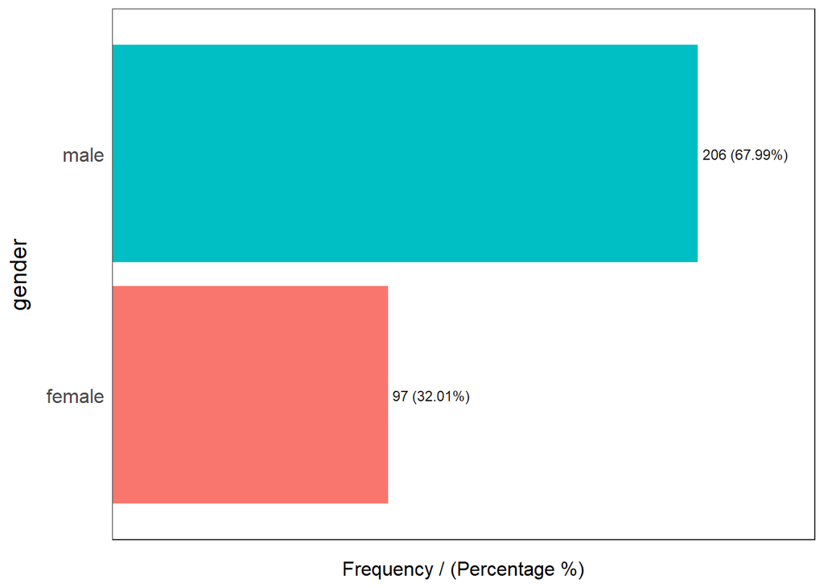

```
##   gender frequency percentage cumulative_perc
## 1   male       206      67.99           67.99
## 2 female        97      32.01          100.00
```

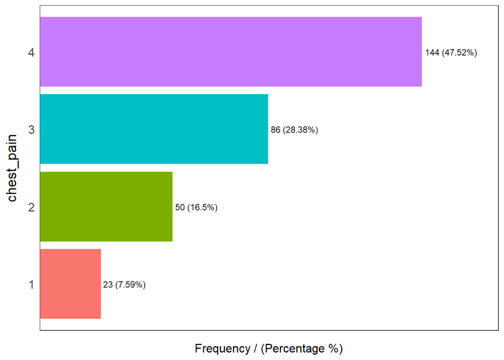

```
##   chest_pain frequency percentage cumulative_perc
## 1          4       144      47.52           47.52
## 2          3        86      28.38           75.90
## 3          2        50      16.50           92.40
## 4          1        23       7.59          100.00
```

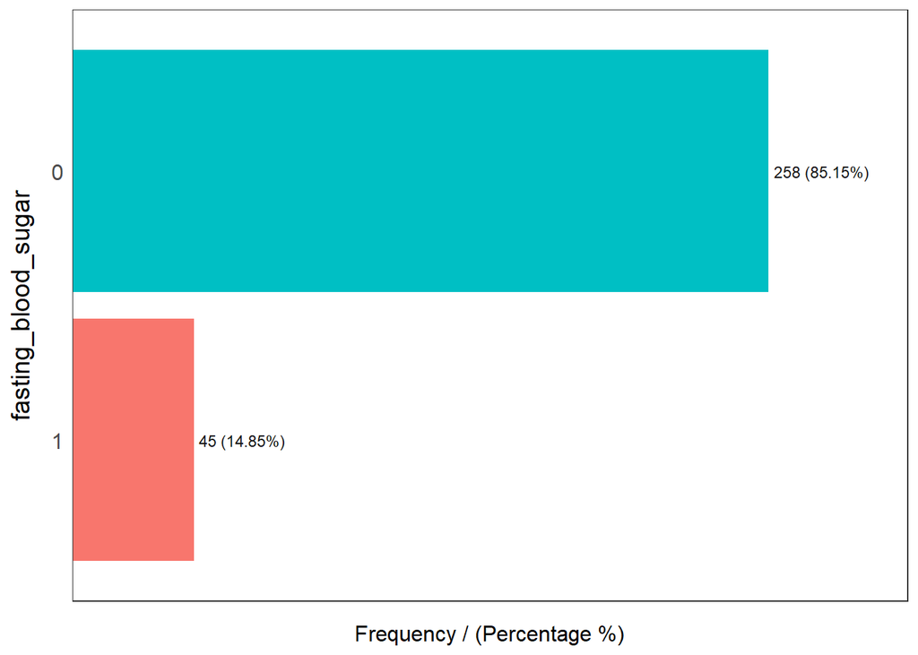

```
##   fasting_blood_sugar frequency percentage cumulative_perc
## 1                   0       258      85.15           85.15
## 2                   1        45      14.85          100.00
```

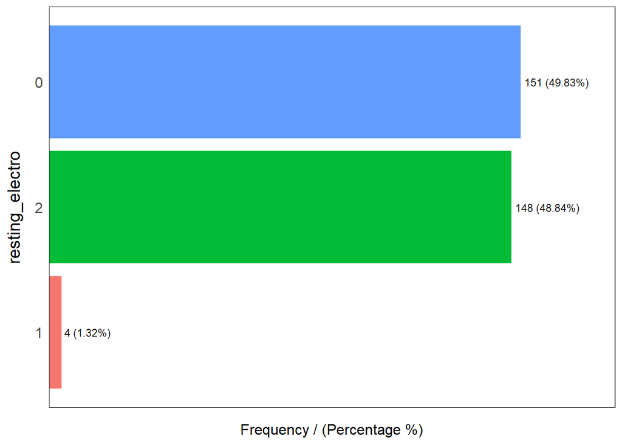

```
##   resting_electro frequency percentage cumulative_perc
## 1               0       151      49.83           49.83
## 2               2       148      48.84           98.67
## 3               1         4       1.32          100.00
```

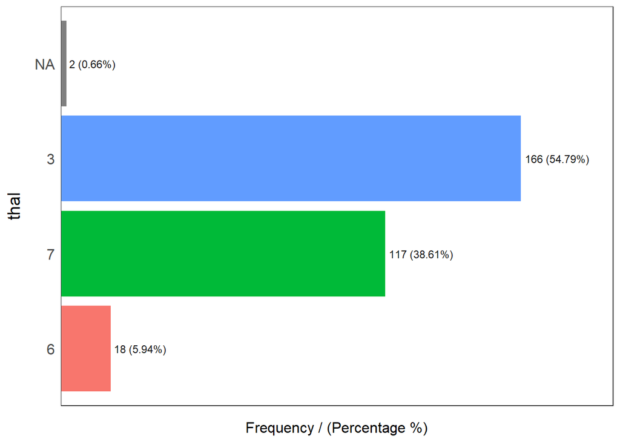

```
##   thal frequency percentage cumulative_perc
## 1    3       166      54.79           54.79
## 2    7       117      38.61           93.40
## 3    6        18       5.94           99.34
## 4 <NA>         2       0.66          100.00
```

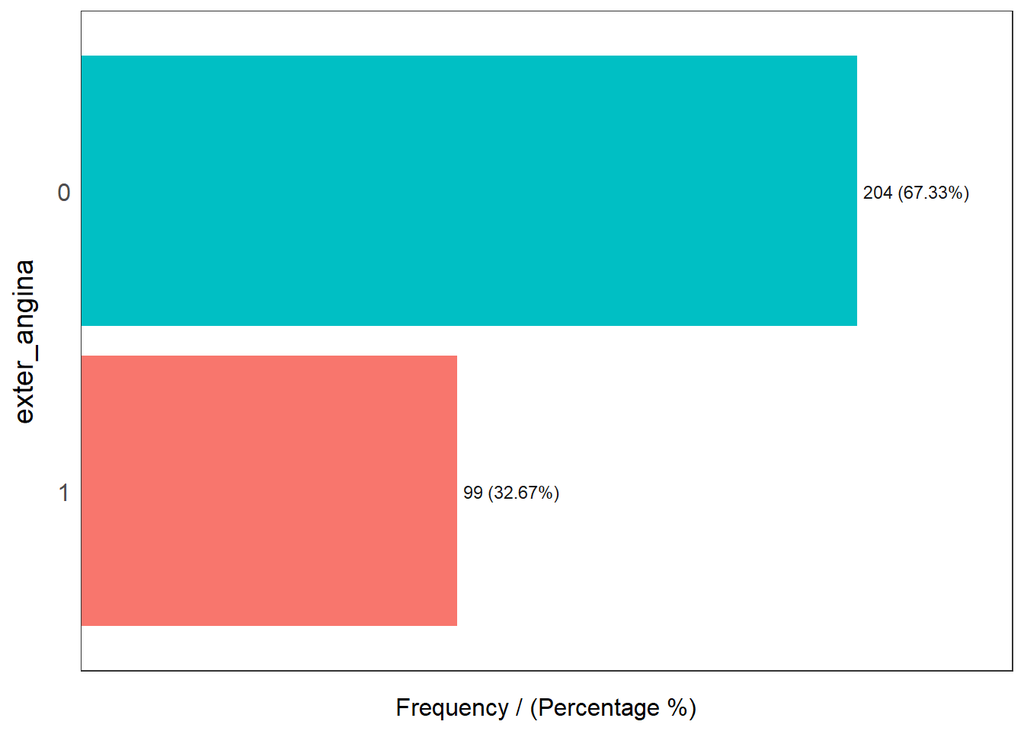

```
##   exter_angina frequency percentage cumulative_perc
## 1            0       204      67.33           67.33
## 2            1        99      32.67          100.00
```

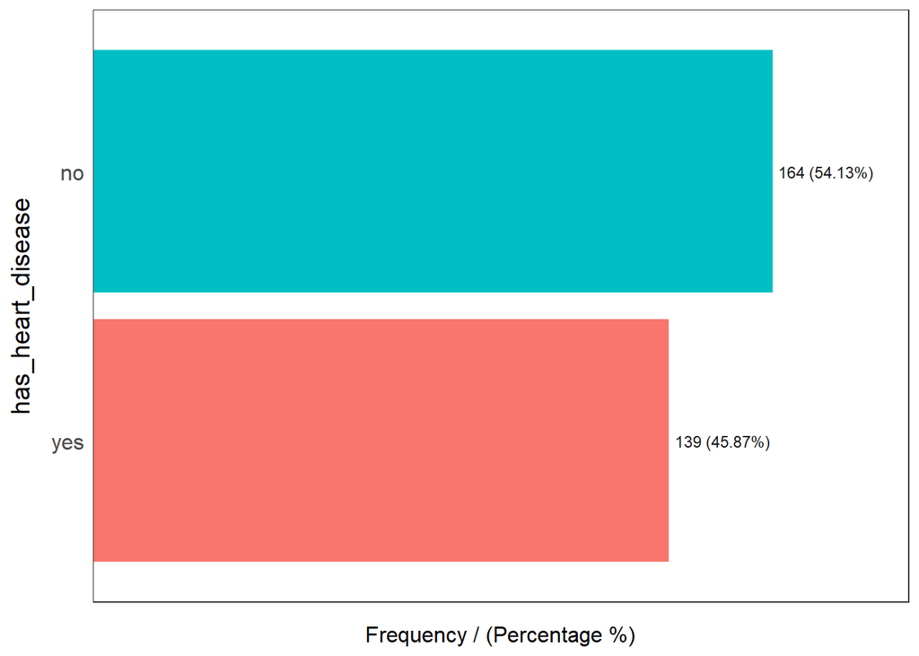

```
##   has_heart_disease frequency percentage cumulative_perc
## 1                no       164      54.13           54.13
## 2               yes       139      45.87          100.00
##
##                 variable   mean std_dev variation_coef p_01 p_05 p_25
## 1                    age  54.44    9.04           0.17   35   40   48
## 2 resting_blood_pressure 131.69   17.60           0.13  100  108  120
## 3      serum_cholestoral 246.69   51.78           0.21  149  175  211
## 4         max_heart_rate 149.61   22.88           0.15   95  108  134
## 5            exer_angina   0.33    0.47           1.44    0    0    0
## 6                oldpeak   1.04    1.16           1.12    0    0    0
## 7                  slope   1.60    0.62           0.38    1    1    1
## 8      num_vessels_flour   0.67    0.94           1.39    0    0    0
## 9 heart_disease_severity   0.94    1.23           1.31    0    0    0
##    p_50  p_75  p_95  p_99 skewness kurtosis  iqr        range_98
```

[output cut: 19 more lines]

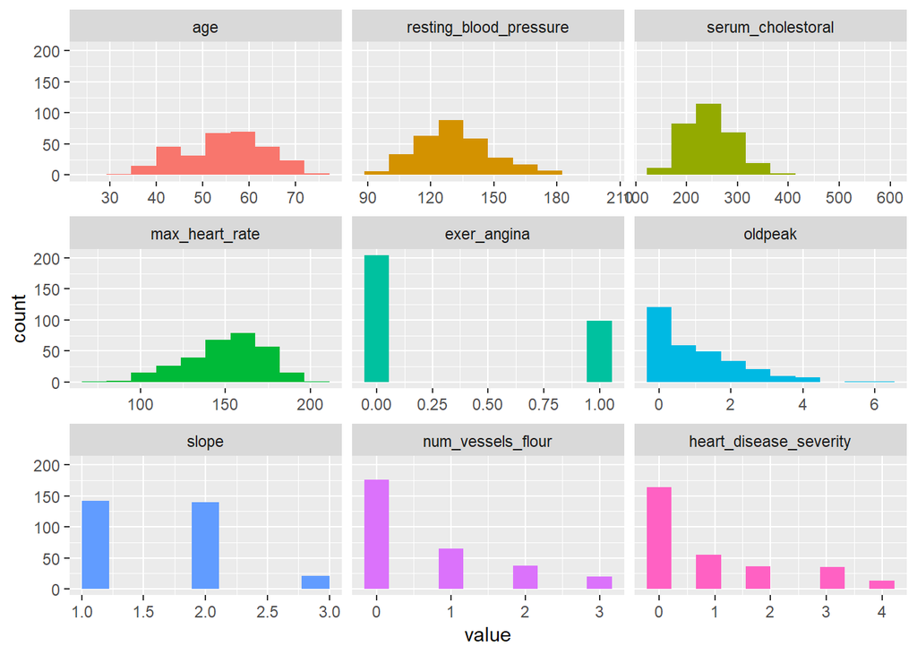

```
## data
##
##  16  Variables      303  Observations
## ---------------------------------------------------------------------------
## age
##        n  missing distinct     Info     Mean      Gmd      .05      .10
##      303        0       41    0.999    54.44     10.3       40       42
##      .25      .50      .75      .90      .95
##       48       56       61       66       68
##
## lowest : 29 34 35 37 38, highest: 70 71 74 76 77
## ---------------------------------------------------------------------------
## gender
##        n  missing distinct
##      303        0        2
##
## Value      female   male
## Frequency      97    206
## Proportion   0.32   0.68
## ---------------------------------------------------------------------------
## chest_pain
##        n  missing distinct
##      303        0        4
##
## Value          1     2     3     4
## Frequency     23    50    86   144
## Proportion 0.076 0.165 0.284 0.475
## ---------------------------------------------------------------------------
## resting_blood_pressure
##        n  missing distinct     Info     Mean      Gmd      .05      .10
##      303        0       50    0.995    131.7    19.41      108      110
##      .25      .50      .75      .90      .95
##      120      130      140      152      160
##
## lowest :  94 100 101 102 104, highest: 174 178 180 192 200
## ---------------------------------------------------------------------------
## serum_cholestoral
##        n  missing distinct     Info     Mean      Gmd      .05      .10
##      303        0      152        1    246.7    55.91    175.1    188.8
##      .25      .50      .75      .90      .95
```

[output cut: 74 more lines]

```
##        n  missing distinct
##      303        0        2
##
## Value         0    1
## Frequency   204   99
## Proportion 0.67 0.33
## ---------------------------------------------------------------------------
## has_heart_disease
##        n  missing distinct
##      303        0        2
##
## Value        no  yes
## Frequency   164  139
## Proportion 0.54 0.46
## ---------------------------------------------------------------------------
```

```r
basic_eda<-function(data){
  glimpse(data)
  df_status(data)
  freq(data)
  profiling_num(data)
  plot_num(data)
  describe(data)
}

basic_eda(heart_disease)
```

## 了解数据

### glimpse()函数

glimpse()函数类似str()函数，给出该数据的观测数（记录数）和字段（变量），在heart_disease中有303条记录和16个变量，同时给出各个变量的类型。

### df_status()函数

df_status()函数返回一个表格，其中包括数据中每一个变量的零值个数，NA值个数，变量类型，唯一值等 一般经常与subset联合使用  
如： *subset(data,data$p_na<20) 筛选出有至少80%的非空值*  
*unique<=50 有少于50个唯一值*  
在做此操作时：  
1、所有变量都是正确的数据类型  
2、有含有很多零或空值的变量码  
3、有高基数变量吗

## 分析分类变量

### freq()函数

freq()函数能够自动的统计数据集中所有因子和字符变量，每个字段中，每一类个数和所占比例以绘图方式给出  
需要存储图片使用：freq(data,path_out=“.”) –这里存储在当前路径中

## 分析数值变量

1、找出极度偏态分布的变量  
2、作图检查任何有异常值的变量  
存储图片：plot_num(data,path_out=“.”)

## 同时分析数值和分类变量

### 使用Hmisc包的describe()函数